[figure not shown]

PI-2

Pre-delivery Inspection

PRE-DELIVERY INSPECTION

1. Pre-delivery Inspection

A: GENERAL DESCRIPTION

The purposes of the pre-delivery inspection (PDI) are as follows.

• Remove the vehicle protective parts for transportation.

• Check that the vehicle or parts before delivery are not damaged during transportation or storage.

• Check that the vehicle after repair is normal.

• Make sure to provide a complete vehicle to customer.

For above reasons, all SUBARU dealer must carry out the PDIs before delivery of vehicle.

Besides, all SUBARU dealer and PDI center check the condition of all vehicles to make sure to take respon-

sibility.

B: PRE-DELIVERY INSPECTION (PDI) PROCEDURE

Static checks just after vehicle receipt

Item Check point

1. Appearance 1. If the vehicle is covered with protective coating, visually check the vehicle body for

damage and dents. If the protective coating has been removed, visually check the

painted body surfaces in detail for damage or rust.

2. Visually check the glass and light lenses for any damage, cracks or excessive gaps

between body panels.

3. Visually check the plated parts for any damage.

4. Check the instrument panel, console and trim for stains or dirt.

2. Tire 1. Check the tires for damage, defective, and dents on wheels.

2. Check the tire air pressure.

3. Fuses If the vehicle is about to be delivered to customer, attach a back-up fuse.

4. Lock/unlock and open/close opera-

tion checks of doors

1. Using the key, check the door can be locked or unlocked normally.

2. Open and close all doors to check that there are no defective.

3. Operate the power door lock switch to check that all doors lock and unlock normally.

5. Child safety lock Check the child safety lock system operates normally.

6. Trunk lid open/close operations 1. Operate the trunk opener button to check that the trunk lid opens normally.

2. Open and close the trunk lid to see that there are no abnormal conditions.

7. Trunk lid release lever Operate the trunk lid release lever to check that the trunk lock is unlocked normally.

8. Fuel lid opener lever Operate the fuel lid opener to check that the fuel lid is unlocked normally.

9. Towing hook (eyebolt) At factory shipment, the towing hook (eyebolt) is installed to the rear bumper. Remove

the towing hook (eyebolt), store it in the holder.

10. Accessory Check that the following accessories are provided.

• Owner’s manual

• Warranty booklet

• Maintenance note

• Spare key

• Key number plate

•Jack

• Tool set

• Spare tire

• Towing hook (eyebolt)

11. Front hood lock release system Operate the front hood lock release lever to check that the front hood opens normally.

12. Battery Check the battery for any abnormal conditions such as rust or traces of battery fluid

leaks.

13. Brake fluid Check the brake fluid amount.

14. Engine oil Check the engine oil amount.

15. Transmission gear oil • Check that the transmission gear oil level is normal. (Except for STI model)

• Check for leakage of the transmission gear oil. (STI model)

16. CVT front differential gear oil Check for no leakage of CVT front differential gear oil.

17. Rear differential gear oil Check for leakage of gear oil from the rear differential.

18. Engine coolant Check the engine coolant level.

19. Clutch fluid Check the clutch fluid amount.

[figure not shown]

PI-3

Pre-delivery Inspection

PRE-DELIVERY INSPECTION

Checks with the engine running

Dynamic test with the vehicle running

20. Window washer fluid Check the window washer fluid amount.

21. Front hood latch Check that the front hood is closed normally and locked securely.

22. Keyless entry system Check that the keyless entry system operates normally.

23. Keyless access system Check that the keyless access function operates normally.

24. Alarm system Check that the alarm system operates normally.

25. Seat 1. Check the seat surfaces for stains or dirt.

2. Check the seat installation conditions and functionality.

26. Seat belt 1. Check the seat belt installation conditions and functionality.

2. Check the seat belt warning system operates normally.

27. TPMS (U.S. model) If the display of TPMS warning light does not operate normally, perform the diagnosis by

referring to TPMS (Diagnosis).

Item Check point

28. Grommet installation Install the grommet provided in the glove box to the tie-down hole.

29. Delivery (test) mode Turn the ignition switch to ON and check that the malfunction indicator light starts blink-

ing.

30. Immobilizer system 1. Check that the engine starts with all keys that are equipped on vehicle.

2. Check that the security indicator light operates normally.

31. Push button start Using the push button start function of the access key equipped with the vehicle, check

that the engine starts and stops.

32. Starting condition Start the engine and check that the engine starts smoothly.

33. Exhaust system Check that the exhaust noise is normal and no leaks are found.

34. Indicator and warning lights Check that all indicator lights and warning lights are operating correctly.

35. Heater & ventilation Check that the heater & ventilation system operates normally.

36. Air conditioner Check that the air conditioner operates normally.

37. Multi-function display (MFD) 1. Check that the Multi-Function Display (MFD) function operates normally.

2. Check that the rearview camera operates normally.

38. Audio Check that all audio functions operate normally.

39. Navigation system 1. Check all display functions for normal operation.

2. Check that the navigation, audio and AUX systems operate normally.

3. Check that the rearview camera operates normally.

40. Accessory power supply socket Check that the accessory power supply socket operates normally.

41. Lighting system Check that the lighting system operates normally.

42. Wiper deicer Check that the wiper deicer operates normally.

43. Illumination control Check that the illumination control operates normally.

44. Window washer Check that the window washer operates normally.

45. Wiper Check that the wiper operates normally.

46. Power window Check that the power window operates normally.

47. Sunroof Check that the sunroof operates normally.

48. Rear defogger Check that the rear defogger operates normally.

49. Door mirror Check that the mirror heater and remote control mirror operate normally.

50. Parking brake Check the parking brake for normal operations.

51. Diagnostic trouble code (DTC)

check

Check that the diagnostic trouble code (DTC) is not detected.

Item Check point

52. Brake test Check the foot brake for normal operations.

53. Shift control Check that the MT, CVT shifts normally.

54. Cruise control Check that the cruise control system operates normally.

Item Check point

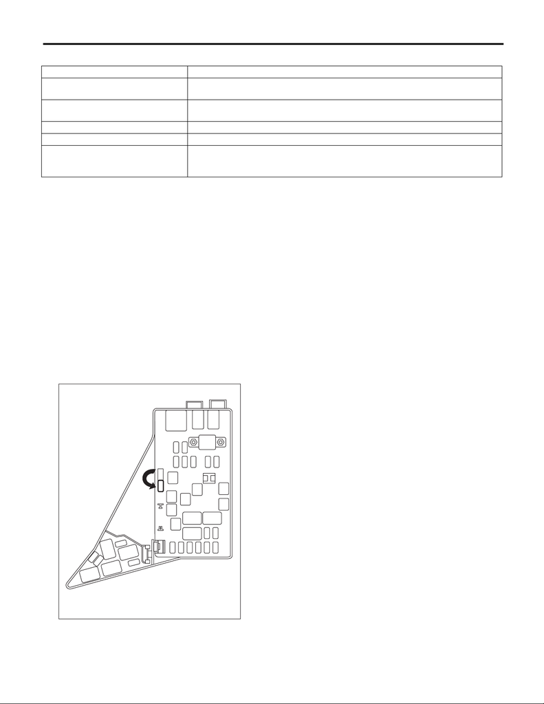

PI-4

Pre-delivery Inspection

PRE-DELIVERY INSPECTION

Checks after dynamic test

1. APPEARANCE

• If the vehicle is covered with protective coating, visually check the vehicle body for damage and dents.

• If the protective coating has been removed, visually check the body painted area for damage or stains in

detail and repair as necessary.

• Visually check the windshield glass, door glasses and light lenses for any damage, cracks or excessive

gaps to the body panel and repair as necessary.

• Visually check the plated parts, such as the grilles and door knobs, for damage or loss of gloss and replace

the parts as necessary.

• Check the instrument panel, console and trim for stains or dirt.

2. TIRE

• Check the tires for damage, defective, and dents on wheels.

• Check and correct the tire size, spare tire and tire air pressure described on the tire air pressure label (driv-

er’s side).

3. FUSE

Fuses for the back-up circuit on initially delivered vehicles are removed to prevent battery discharge. Attach

the 20 A fuse as shown in the figure.

Item Check point

55. Power steering system

(hydraulic power steering model)

Check that the power steering fluid level is normal.

56. Power steering system

(electric power steering model)

Check the steering warning light operation.

57. Fluid leakage Check for fluid/oil leaks.

58. Water leakage Spray the vehicle with water and check for water leaks.

59. Appearance 2 1. Remove the protective coat. (If attached)

2. Check the body paints for damage and stain.

3. Check the plated parts for damage and rust.

NT-00426

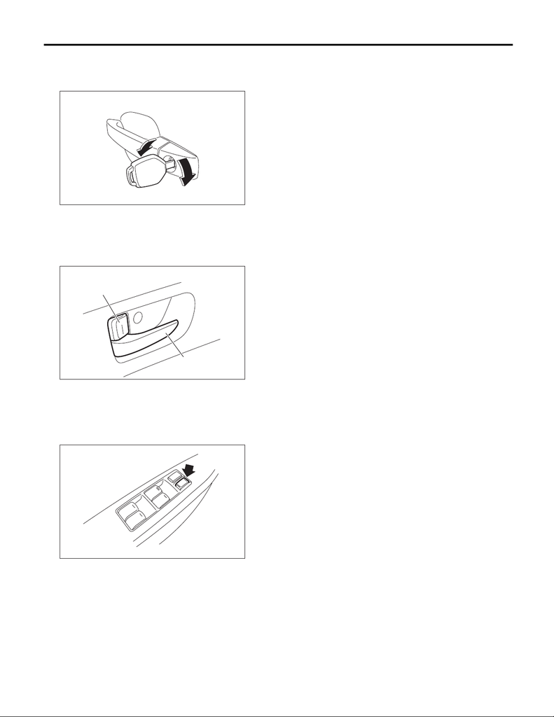

PI-5

Pre-delivery Inspection

PRE-DELIVERY INSPECTION

4. LOCK/UNLOCK AND OPEN/CLOSE OPERATION CHECKS OF DOORS

1) Using the key, lock and unlock the door several times to check for normal operation. Open and close the

door several times for smooth movement.

2) Completely close the driver’s door, and then check the smooth movement with operating door lock knob

from lock to unlock several times. Set the door lock knob (A) to lock position. Then pull the inner remote (B)

to ensure that doors will not open.

For other doors, place the door lock knob (A) to lock position and then pull the inner remote (B) to ensure that

doors will not open.

3) Close all the doors, and then press the lock on power door lock switch at driver’s side. Check that all doors

lock.

PI-00604

PI-00688

(A)

(B)

(A) Door lock knob

(B) Inner remote

PI-00689

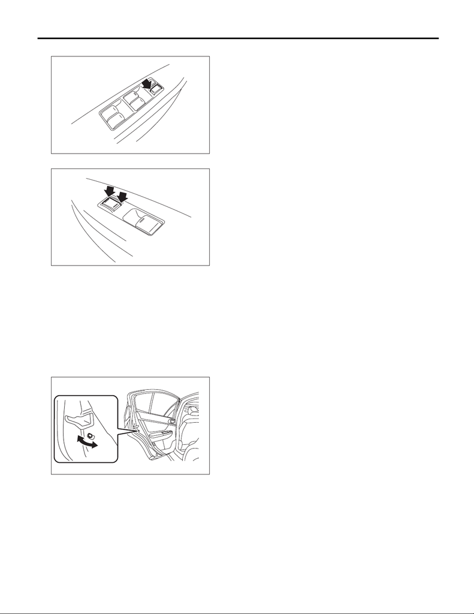

PI-6

Pre-delivery Inspection

PRE-DELIVERY INSPECTION

4) Press the driver’s side power door lock switch to unlock side. Check that all doors are unlocked.

5) Check that the passenger’s power door lock switch locks and unlocks normally in the same manner.

6) With ACC ON or IGN ON, open the driver’s door. Press lock on power door lock. Check that the door is

not locked.

5. CHILD SAFETY LOCK SYSTEM

1) Set the child safety lock on both rear doors to the lock position.

2) Close the rear doors completely.

3) Check that the lock levers of the rear doors are in the unlock position. Then, pull inner remote of rear doors

to ensure that the doors will not open.

4) Pull the outer handles of rear doors to ensure that the doors will open.

6. TRUNK LID OPEN/CLOSE OPERATIONS

1) Operate the trunk opener button to check that the trunk lid opens.

2) Open and close the trunk lid several times for smooth movement.

PI-00690

PI-00691

(A)

(B)

(A) Lock

(B) Unlock

PI-00870

(A)

(B)

(A) Unlock

(B) Lock

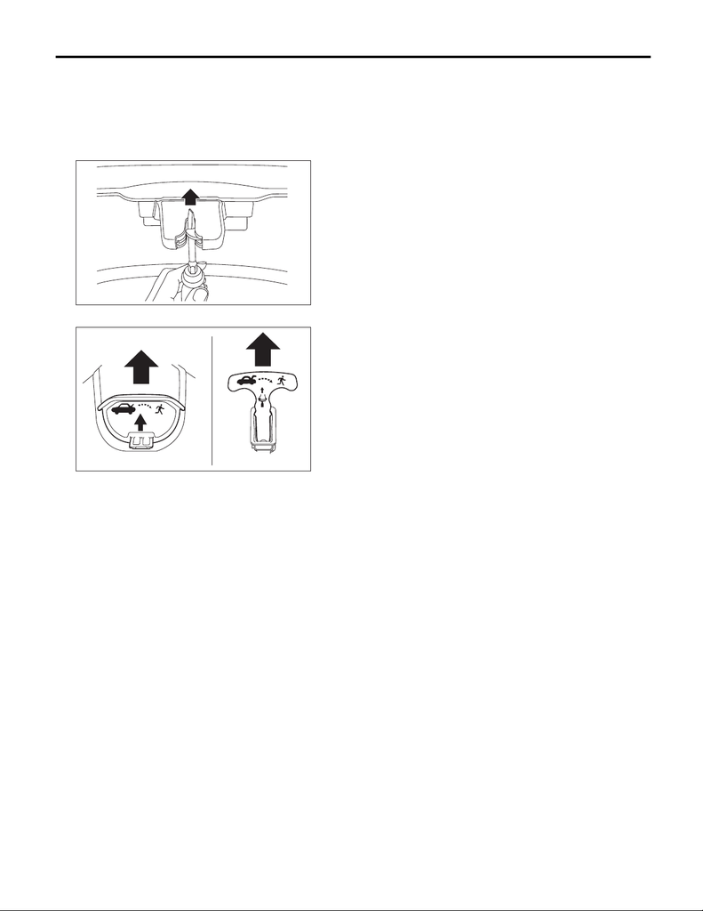

PI-7

Pre-delivery Inspection

PRE-DELIVERY INSPECTION

7. TRUNK LID RELEASE LEVER OPERATIONS

CAUTION:

Do not check the trunk lid release lever when in the trunk. If the trunk lid release lever is defective,

you may be trapped in.

1) Use a flat tip screwdriver. Slide the screwdriver blade from the slit aperture of the lock assembly fully to the

end until you hear a click. This places the latch in the locked position.

2) Make sure the latch is released by pulling the yellow trunk lid release lever in the direction of arrow.

8. FUEL LID OPENER LEVER

Operate the fuel lid opener to check that the fuel filler lid can be unlocked normally. Check that the filler cap

is securely closed.

PI-00874

PI-00914

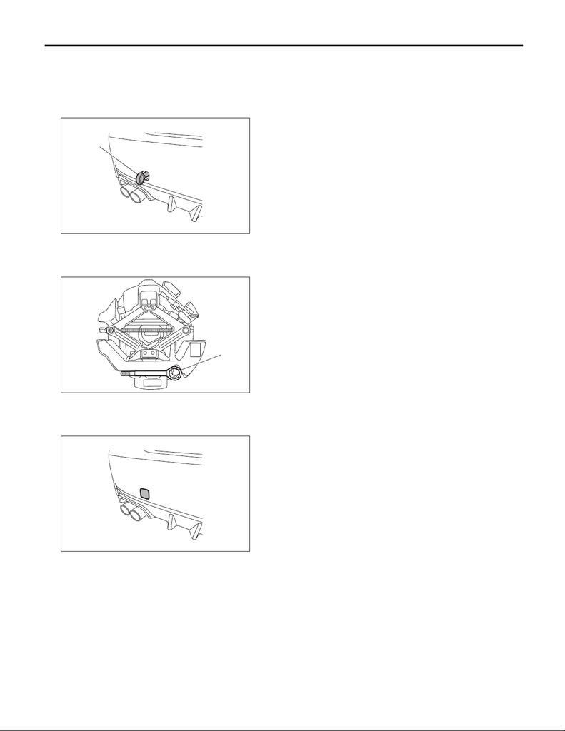

PI-8

Pre-delivery Inspection

PRE-DELIVERY INSPECTION

9. TOWING HOOK (EYEBOLT)

NOTE:

At factory shipment, the towing hook (eyebolt) is installed to the rear bumper for securing the vehicle during

transportation. Follow the procedure below to store the towing hook (eyebolt) to the holder in the spare tire.

1) Remove the towing hook (eyebolt) from the rear bumper.

2) Store the towing hook (eyebolt) to the holder in the spare tire.

3) Install the supplied rear hook cover to rear bumper.

PI-00871

(A)

(A) Towing hook (eyebolt)

PI-00872

(A)

(A) Towing hook (eyebolt)

PI-00877

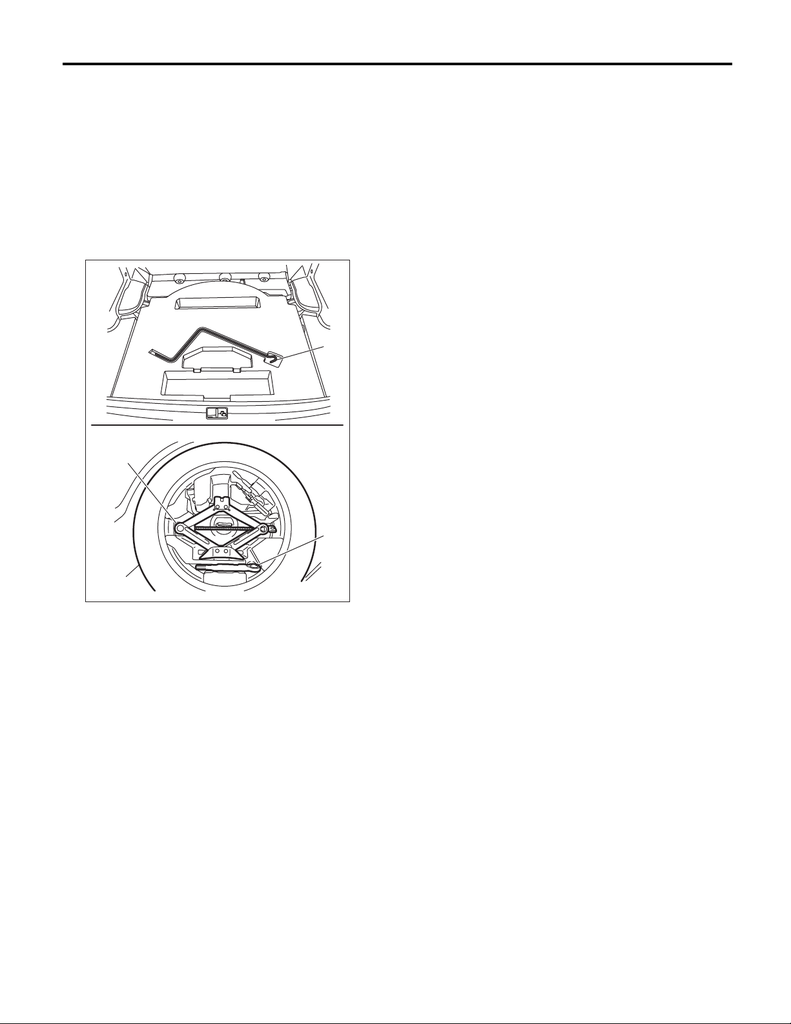

PI-9

Pre-delivery Inspection

PRE-DELIVERY INSPECTION

10.ACCESSORY

Check that the following accessories are provided.

• Owner’s manual

• Warranty booklet

• Maintenance note

• Spare key

• Key number plate

•Jack

•Tool set

• Spare tire

• Towing hook (eyebolt)

PI-00860

(A)

(C)

(B)

(

D)

(A) Jack handle

(B) Spare tire

(C) Jack

(D) Towing hook (eyebolt)

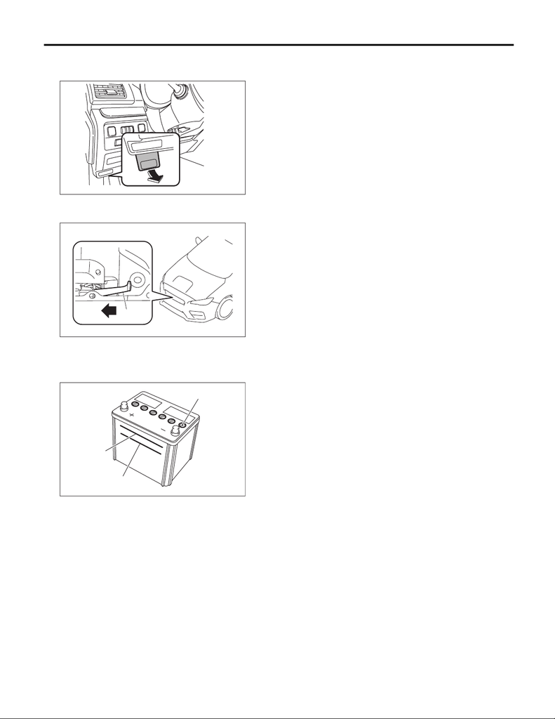

PI-10

Pre-delivery Inspection

PRE-DELIVERY INSPECTION

11.FRONT HOOD LOCK RELEASE SYSTEM

Operate the front hood lock release lever to check that the front hood is unlocked normally.

Operate the lever (A) and check that the front hood is opened normally. Check that the front hood can be sup-

ported by damper stay.

12.BATTERY

Check the battery terminals to make sure that there are no rust or corrosion due to fluid leaks. Check that the

battery caps are securely tightened.

PI-00700

PI-00875

(A)

PI-00012

(A)

(B)

(C)

(A) Cap

(B) Upper level

(C) Lower level

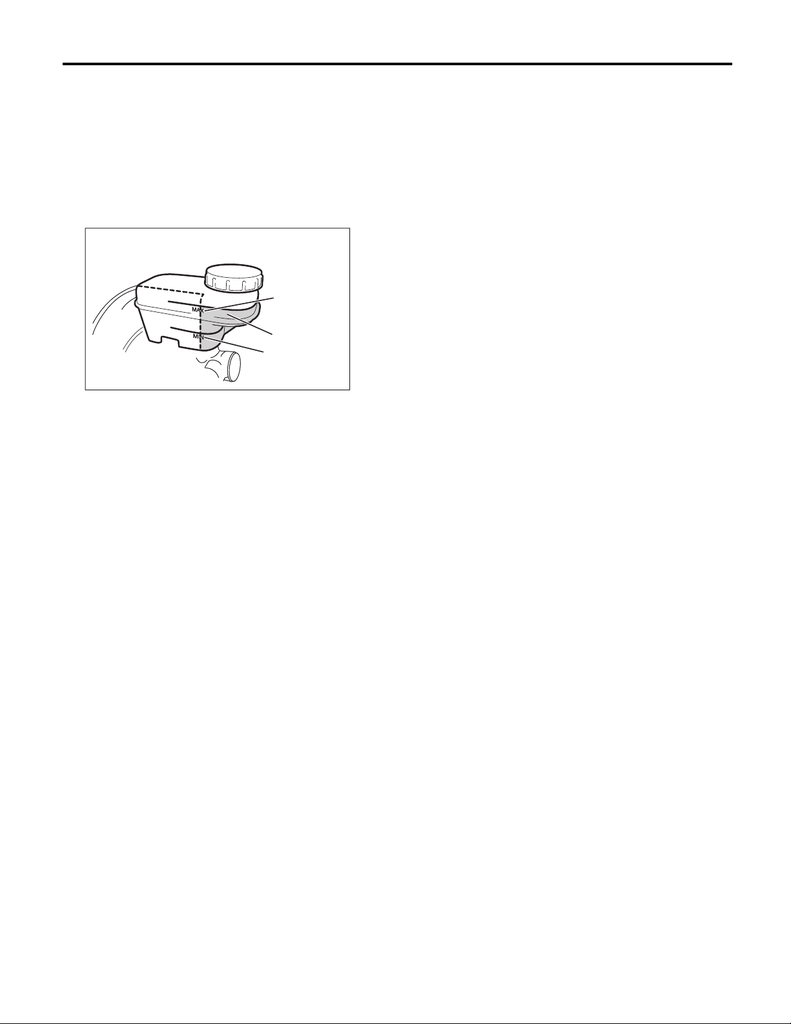

PI-11

Pre-delivery Inspection

PRE-DELIVERY INSPECTION

13.BRAKE FLUID

CAUTION:

• If the brake fluid is spilt over exhaust pipe, wipe it off with cloth to avoid emitting smoke or causing

a fire.

• Always check the level using the specified direction because there is a partition in the reservoir

tank.

Check that the brake fluid level is normal from a straight view or within 90° to the right and left forward. If the

amount is insufficient, carry out a brake line test to identify brake fluid leaks and check the brake operation.

After that, refill the brake fluid tank with the specified type of fluid.

14.ENGINE OIL

CAUTION:

If the engine oil is spilt over exhaust pipe or the under cover, wipe it off with cloth to avoid emission

of smoke or causing a fire.

1) Park the vehicle on a level surface.

2) Remove the oil level gauge and wipe away the oil.

3) Reinsert the oil level gauge all the way. Be sure that the oil level gauge is correctly inserted and properly

orientated.

4) Pull out the oil level gauge again, and check both sides of the oil level gauge. Use a lower side to deter-

mine the engine oil level. If the engine oil level is below “L” line, add oil to bring the level up to “F” line.

5) Start the engine, and spread the oil in engine room.

PI-00833

(A)

(B)

(C)

(A) MIN. level

(B) MAX. level

(C) Brake fluid

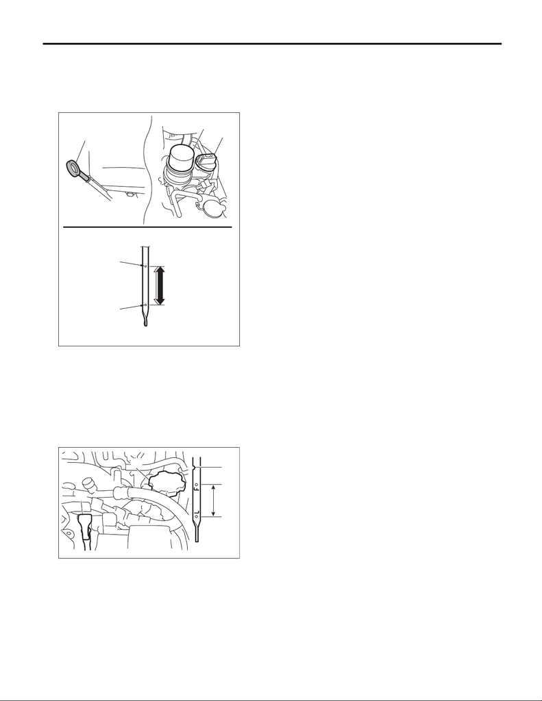

PI-12

Pre-delivery Inspection

PRE-DELIVERY INSPECTION

6) After turning off the engine, wait a few minutes for the oil to return to the oil pan before checking the oil lev-

el.

NOTE:

To prevent overfilling of engine oil, do not add oil above “F” line when the engine is cold.

• Except for STI model

• STI model

PI-00881

(D)

(E)

(F)

(B)

(A)

(C)

(A) Engine oil level gauge

(B) Engine oil filler cap

(C) Engine oil filter

(D) “F” line

(E) “L” line

(F) Approx. 1.0 L (1.1 US qt, 0.9 Imp qt)

(C)

(B)

(D)

(E)

(F)

(A)

PI-00460

(A) Engine oil level gauge

(B) Engine oil filler cap

(C) “F” line

(D) “L” line

(E) Approx. 1.0 L (1.1 US qt, 0.9 Imp qt)

(F) Notch mark

PI-13

Pre-delivery Inspection

PRE-DELIVERY INSPECTION

15.TRANSMISSION GEAR OIL

CAUTION:

If transmission gear oil is spilt over the exhaust pipe, wipe it off with a cloth to avoid emitting smoke

or causing a fire.

Except for STI model

Check that the transmission gear oil level is normal. If the amount of gear oil is insufficient, check that no

leaks are found. Then add the necessary amount of the specified transmission gear oil.

Refer to “6MT” section for transmission gear oil inspection. <Ref. to 6MT(TY75)-23, INSPECTION, Trans-

mission Gear Oil.>

STI model

Check for leakage of the transmission gear oil.

16.CVT FRONT DIFFERENTIAL GEAR OIL

CAUTION:

If gear oil is spilt over the exhaust pipe, wipe it off with a cloth to avoid emitting smoke or causing a

fire.

Check for no leakage of CVT front differential gear oil.

17.REAR DIFFERENTIAL GEAR OIL

CAUTION:

If the rear differential gear oil is spilt over exhaust pipe, wipe it off with cloth to avoid emitting smoke

or causing a fire.

Check for leakage of gear oil from the rear differential.

18.ENGINE COOLANT

CAUTION:

If the engine coolant is spilt over exhaust pipe, wipe it off with cloth to avoid emitting smoke or caus-

ing a fire.

Check that the engine coolant level on the reservoir tank is normal. If the amount of engine coolant is insuf-

ficient, check that no leaks are found. Then, add the necessary amount of coolant with the specified concen-

tration.

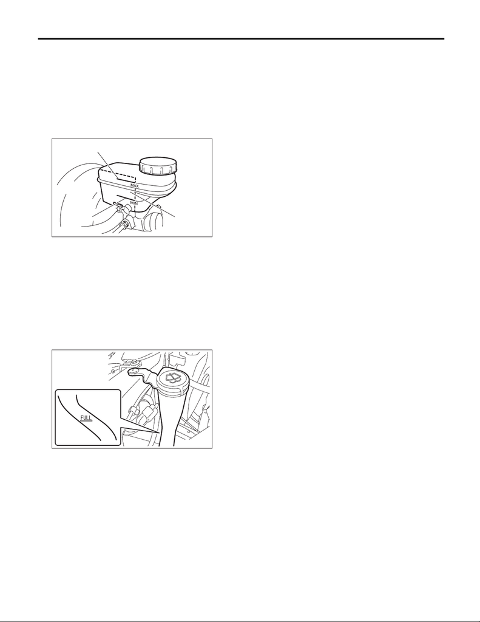

PI-14

Pre-delivery Inspection

PRE-DELIVERY INSPECTION

19.CLUTCH FLUID

CAUTION:

• If any clutch fluid is spilt on the exhaust pipe, wipe it off with a cloth to avoid emitting smoke or

causing a fire.

• This reservoir tank has the brake fluid chamber and the clutch fluid chamber. When checking the

fluid level, always check the fluid from the clutch fluid chamber side where the tank hose is connect-

ed.

Check that the clutch fluid level is normal. If the amount of fluid is insufficient, check that no leaks are found.

Then, add the necessary amount of specified fluid.

20.WINDOW WASHER FLUID

Check that the window washer fluid level is normal. If the amount of washer fluid is insufficient, check that no

leaks are found. Then, add the necessary amount of washer fluid.

NOTE:

If there is the vibration, water comes into the layer of air in the washer tank and the water level may drop. This

is not a malfunction.

21.FRONT HOOD LATCH

Close the front hood. Check that the front hood is securely latched.

PI-00840

(C)

(A)

(B)

(A) Clutch fluid chamber

(B) MAX. level

(C) MIN. level

PI-00879

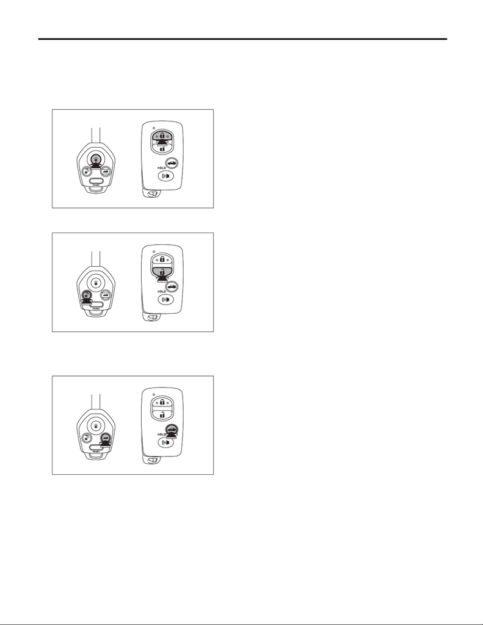

PI-15

Pre-delivery Inspection

PRE-DELIVERY INSPECTION

22.KEYLESS ENTRY SYSTEM

Check the keyless entry system operations as follows:

• Fully open all the door windows.

• Remove the key from ignition switch, and then close all doors.

• Press the “LOCK/ARM” button momentarily. Check that all the doors become locked, the buzzer sounds

once, and the hazard lights flash once.

• Press the “UNLOCK/DISARM” button momentarily. Check that the driver’s door is unlocked, the buzzer

sounds twice, and the hazard lights flash twice.

• Within 5 seconds, press the “UNLOCK/DISARM” button momentarily. Check that all doors are unlocked,

the buzzer sounds twice, and the hazard lights flash twice.

• Check that the buzzer sounds twice, and the hazard lights flash twice, when the trunk lid unlock button is

held down to unlock the trunk lid.

PI-00850

PI-00851

PI-00852

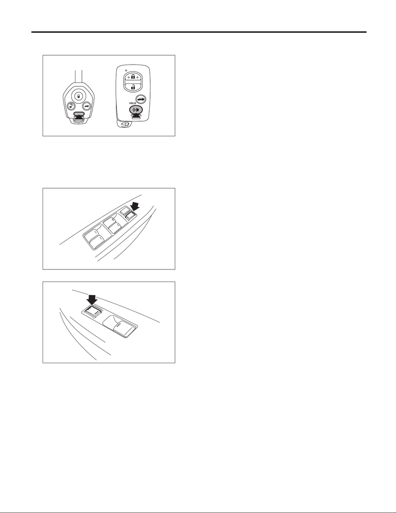

PI-16

Pre-delivery Inspection

PRE-DELIVERY INSPECTION

• Press the “PANIC” button. Check that the panic mode (the horn keeps sounding) is initiated. Also, check

that this condition continues for 30 seconds or until when any of the buttons on the key are pressed.

• Press the “LOCK/ARM” button momentarily with one of the doors opened. Check that the buzzer sounds

5 times, and the hazard light flashes 5 times to notify the door not being fully closed. Then, close all doors.

Check if all doors are locked and buzzer sounds once and the hazard light flashes once.

• With one of the doors open, press the “LOCK” side of the power door lock switch. Then, close all doors.

Check if all doors are locked and buzzer sounds once and the hazard light flashes once.

• Driver’s side

• Passenger’s side

Check keyless answer-back buzzer operation

• The system uses the buzzer and sounds the keyless answer-back buzzer when the door is locked or un-

locked. The keyless answer-back buzzer can be turned OFF. To turn the keyless answer-back buzzer from

ON to OFF, close all doors, (with the key not inserted into the key cylinder), hold down the “UNLOCK” side

of the power door lock switch and insert the key into the key cylinder. Within 10 seconds, insert and take out

the key for 5 times or more, and within 10 seconds after that, open and close the driver’s door. With the door

closed, the hazard light will flash 3 times, indicating that the keyless answer-back buzzer has been turned

OFF. To turn the keyless answer-back buzzer from OFF to ON, perform this procedure again. The hazard

light will flash 3 times, indicating that the keyless answer-back buzzer has been turned ON.

PI-00853

PI-00689

PI-00709

[figure not shown]

PI-17

Pre-delivery Inspection

PRE-DELIVERY INSPECTION

23.KEYLESS ACCESS FUNCTION

CAUTION:

• When performing the check, check one access key at a time, separating individual keys.

• Do not leave any separated access keys in the vehicle.

• Fully open all the door windows.

NOTE:

The following inspections show the initial settings. When the settings are different from the initial settings, use

Subaru Select Monitor to check the details of each setting for inspections. <Ref. to BC(diag)-15, OPERA-

TION, Read Current Data.>

• While carrying the access key, check that the room light illuminates when you move close to the front door

handles of the vehicle whose doors are all locked.

• While carrying the access key, check that the driver’s door is unlocked, the buzzer sounds, and the hazard

light blinks by grasping the front door knob (touching the touch sensor on the driver’s side (unlock)).

• While carrying the access key, check that all doors are unlocked, the buzzer sounds, and the hazard light

blinks by grasping the front door knob (touching the touch sensor on the passenger’s side (unlock)).

• While carrying the access key, check that all doors are locked, the buzzer sounds, and the hazard light

blinks by touching the touch sensor (lock) of the front door.

NOTE:

• The hazard lights flash twice and the buzzer sounds twice when unlocking.

• The hazard lights flash once and the buzzer sounds once when locking.

• Manually operate the access key button to check the lock/unlock of doors, flashing of hazard lights, and

sounding of the buzzer.

• Check the mechanical key attached to the access key can be used for locking/unlocking.

• With the access key in the vehicle, check that warning buzzer sounds and locking does not occur when you

touch the touch sensor on the door (lock).

CAUTION:

Remove the mechanical key from the access key and hold the mechanical key.

PI-00876

(A)

(A) Touch sensor (lock)

PI-00732

(A)

(A) Mechanical key

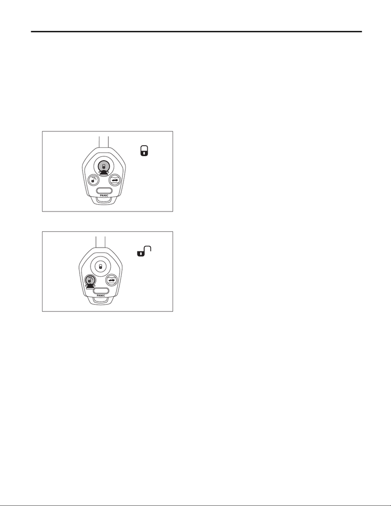

PI-18

Pre-delivery Inspection

PRE-DELIVERY INSPECTION

24.ALARM SYSTEM

• Model without keyless access function

NOTE:

The following inspections show the initial settings. When the settings are different from the initial settings, use

Subaru Select Monitor to check the details of each setting for inspections. <Ref. to BC(diag)-22, OPERA-

TION, Registration Body Integrated Unit.>

1) Fully open all the door windows.

2) Remove the key from ignition switch, and then close all doors.

3) Press the “LOCK” button momentarily on the keyless transmitter. All doors are locked, and the security in-

dicator light blinks faster for 30 seconds and blinks slowly twice repeatedly, then the alarm system is in set

condition.

4) Press the “UNLOCK” button momentarily on the keyless transmitter. When the door of the driver’s seat is

unlocked, the security indicator light blinks, and the alarm system enters the release mode.

5) Press the “LOCK” button once on the keyless transmitter with one of the doors open. Check that the buzz-

er sounds 5 times to give the door not fully closed warning. All doors are locked when they are closed, and

the security indicator light blinks faster for 30 seconds and blinks slowly twice repeatedly, then the alarm sys-

tem is in set condition.

6) Press the “UNLOCK” button momentarily on the keyless transmitter. When the door of the driver’s seat is

unlocked, the security indicator blinks, and the alarm system enters the release mode.

PI-00705

PI-00706

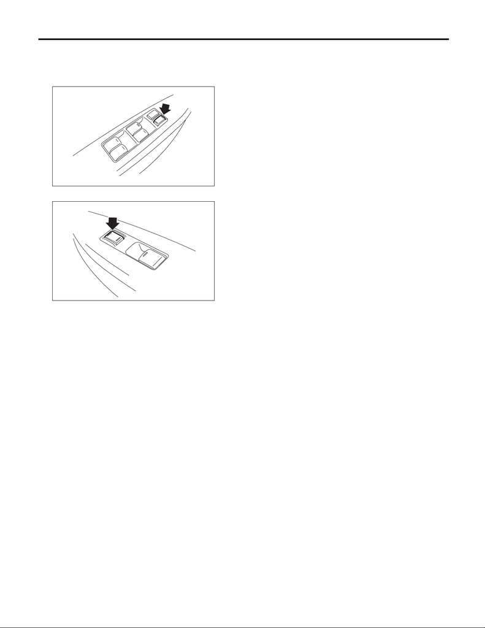

PI-19

Pre-delivery Inspection

PRE-DELIVERY INSPECTION

7) With one of the doors open, press the “LOCK” side of the power door lock switch. All doors are locked

when they are closed, and the security indicator light blinks faster for 30 seconds and blinks slowly twice re-

peatedly, then the alarm system is in set condition.

• Driver’s side

• Passenger’s side

8) Unlock a door using the inner lock knob or the key and open the door while the security system is in the

set mode. Check if the alarm condition occurs (horn sounds continuously, hazard light blinks, security indi-

cator light illuminates). Check if this condition lasts until any button of the keyless transmitter is pressed or un-

til the ignition switch is turned to IGN ON after inserting the key into the ignition switch.

NOTE:

The alarm sounds for three minutes with the door open.

9) On models equipped with an impact sensor, hit the windshield glass with your hand with the alarm system

in the monitoring condition, to check that the alarm condition occurs.

10) Turn the ignition switch to ON and check that the security indicator light indicates the alarm history.

NOTE:

• When alarm history for the opening of door is present, the security indicator light illuminates for one second

and then blinks 5 times.

• When alarm history for the opening of trunk is present, the security indicator light illuminates for one sec-

ond and then blinks 4 times.

• When alarm history for the impact sensor is present, the security indicator light illuminates for one second

and then blinks twice.

• When warning history for the impact sensor is present, the security indicator light illuminates for one sec-

ond and then blinks once.

• When more than one histories are present, the alarm history with higher priority is indicated (higher priority

from above).

11) Press the “LOCK” button on the keyless transmitter momentarily to arm the alarm system. Press the “UN-

LOCK” button on the keyless transmitter momentarily to disarm the alarm system.

12) Turn the ignition switch to ON and check that the security indicator light does not indicate the alarm his-

tory. (The security indicator light remains OFF.)

13) When none of above is applicable, perform troubleshooting for the security system.

PI-00689

PI-00709

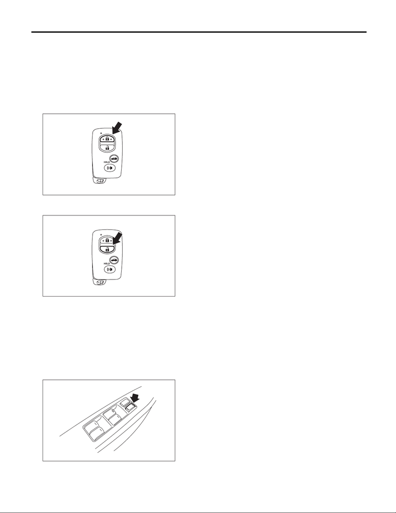

PI-20

Pre-delivery Inspection

PRE-DELIVERY INSPECTION

• Model with keyless access function

NOTE:

The following inspections show the initial settings. When the settings are different from the initial settings, use

Subaru Select Monitor to check the details of each setting for inspections. <Ref. to BC(diag)-22, OPERA-

TION, Registration Body Integrated Unit.>

1) Fully open all the door windows.

2) Turn the ignition switch to OFF and close all doors.

3) Press the “LOCK” button momentarily on the access key. All doors are locked, and the security indicator

light blinks faster for 30 seconds and blinks slowly twice repeatedly, then the alarm system is in set condition.

4) Press the “UNLOCK” button momentarily on the access key. When the door of the driver’s seat is un-

locked, the security indicator light blinks, and the alarm system enters the release mode.

5) Press the “LOCK” button once on the access key with one of the doors open. Check that the buzzer

sounds 5 times to give the door not fully closed warning. All doors are locked when they are closed, and the

security indicator light blinks faster for 30 seconds and blinks slowly twice repeatedly, then the alarm system

is in set condition.

6) Press the “UNLOCK” button momentarily on the access key. When the door of the driver’s seat is un-

locked, the security indicator blinks, and the alarm system enters the release mode.

7) With one of the doors open, press the “LOCK” side of the power door lock switch. All doors are locked

when they are closed, and the security indicator light blinks faster for 30 seconds and blinks slowly twice re-

peatedly, then the alarm system is in set condition.

• Driver’s side

PI-00813

PI-00814

PI-00689

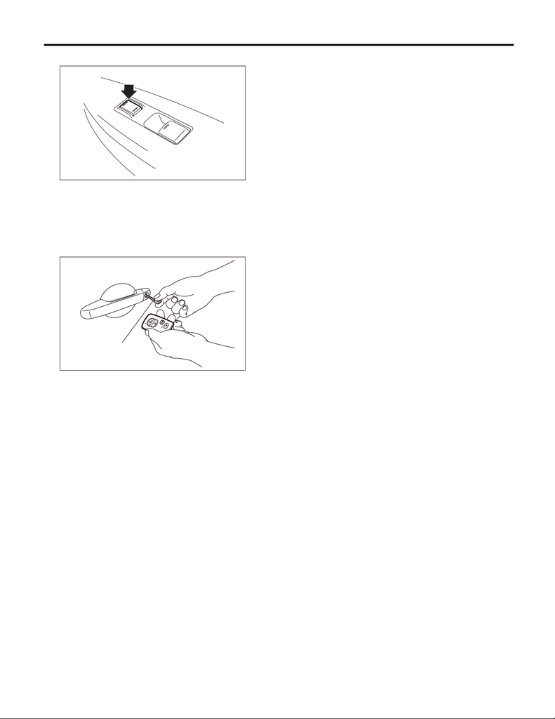

PI-21

Pre-delivery Inspection

PRE-DELIVERY INSPECTION

• Passenger’s side

8) Unlock a door using the mechanical key and open the door while the security system is in the set mode.

Check if the alarm condition occurs (horn sounds continuously, hazard light blinks, security indicator light il-

luminates). Check if this condition lasts until any button on the access key is pressed or until the ignition

switch is turned to ACC.

NOTE:

The alarm sounds for three minutes with the door open.

9) On models equipped with an impact sensor, hit the windshield glass with your hand with the alarm system

in the monitoring condition, to check that the alarm condition occurs.

10) Turn the ignition switch to ON and check that the security indicator light indicates the alarm history.

NOTE:

• When alarm history for the opening of door is present, the security indicator light illuminates for one second

and then blinks 5 times.

• When alarm history for the opening of trunk is present, the security indicator light illuminates for one sec-

ond and then blinks 4 times.

• When alarm history for the impact sensor is present, the security indicator light illuminates for one second

and then blinks twice.

• When warning history for the impact sensor is present, the security indicator light illuminates for one sec-

ond and then blinks once.

• When more than one histories are present, the alarm history with higher priority is indicated (higher priority

from above).

11) Press the “LOCK” button on the access key momentarily to arm the alarm system. Press the “UNLOCK”

button on the access key momentarily to disarm the alarm system.

12) Turn the ignition switch to ON and check that the security indicator light does not indicate the alarm his-

tory. (The security indicator light remains OFF.)

13) When none of above is applicable, perform troubleshooting for the security system.

PI-00709

PI-00786

(A)

(A) Mechanical key

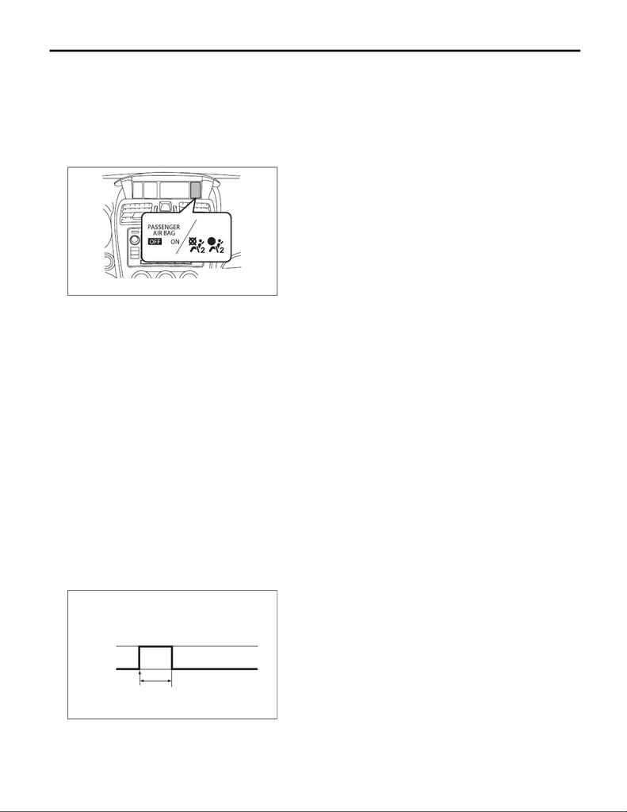

PI-22

Pre-delivery Inspection

PRE-DELIVERY INSPECTION

25.SEAT

1) Check the seat surfaces for stains or dirt.

2) Check that each seat provides full functionality in sliding, reclining, lifter, and tilting. Check all available

functions of the rear seat such as backrest tilt knob.

3) Check the passenger’s seat occupant detection system.

(1) Empty the passenger’s seat and turn the ignition switch to ON.

(2) Check that the passenger airbag ON/OFF indicator lights both turn on simultaneously for approxi-

mately six seconds, and after turning off for two seconds, only the OFF light illuminates.

4) With a person weighing approximately 70 kg (155 lb) or more sitting in the passenger’s seat, check wheth-

er the ON light of the passenger’s airbag ON/OFF indicator illuminates or not.

5) Have the passenger get out of the passenger’s seat, and check whether the OFF light of the passenger

side airbag ON/OFF indicator illuminates.

26.SEAT BELT

1) Check installation condition of seat belt.

2) Pull out the seat belt and then release it. Check that the belt retracts smoothly.

3) Check seat belt warning function.

(1) Turn the ignition switch to ON with the driver’s and passenger’s seat belt detached.

(2) Check the driver’s and passenger’s seat belt warning light blink for approx. 6 seconds and the buzzer

sounds intermittently.

(3) Then, check the seat belt warning light illuminates and blinks repeatedly at a cycle of approx. 15 sec-

onds. (If no passenger is on the passenger’s seat, the seat belt warning light on passenger’s seat does

not operate.)

27.TPMS (U.S. MODEL)

1) Turn the ignition switch to ON, and check that the TPMS warning light is in a normal operation condition.

• Normal operation (IG ON (light check))

2) If the TPMS warning light display does not operate normally, check and repair the system. <Ref. to

TPM(diag)-2, Basic Diagnostic Procedure.>

PI-00882

(A)

(B)

(A) Airbag ON/OFF indicator light (U.S. (U5) model)

(B) Airbag ON/OFF indicator light (Canada (C0),

Mexico (C4) models)

2s

IGN ON

ON

OFF

PI-00376

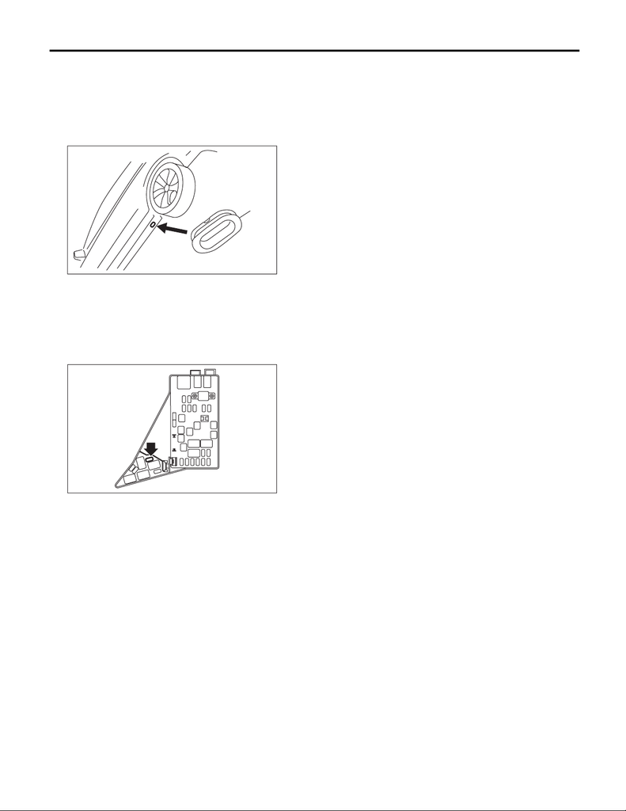

PI-23

Pre-delivery Inspection

PRE-DELIVERY INSPECTION

28.GROMMET INSTALLATION

Install the grommet provided in the glove box to the tie-down hole.

CAUTION:

Make sure that the tie-down hole is firmly plugged with the grommet. Otherwise, dust, smell, etc. may

come into the passenger compartment indirectly from the rear quarter, via the side sill from the tie-

down hole.

29.DELIVERY (TEST) MODE

1) Turn the ignition switch to ON and check that the malfunction indicator light starts blinking.

2) If the light blinks, return the ignition key to LOCK.

3) Remove the D check fuse and attach it to the spare fuse holder provided on the fuse box cover.

4) Then, turn the ignition key to ON again.

5) Make sure that the malfunction indicator light is off. If the malfunction indicator light blinks, carry out an en-

gine diagnosis.

PI-00854

(1)

(1) Grommet

PI-00715

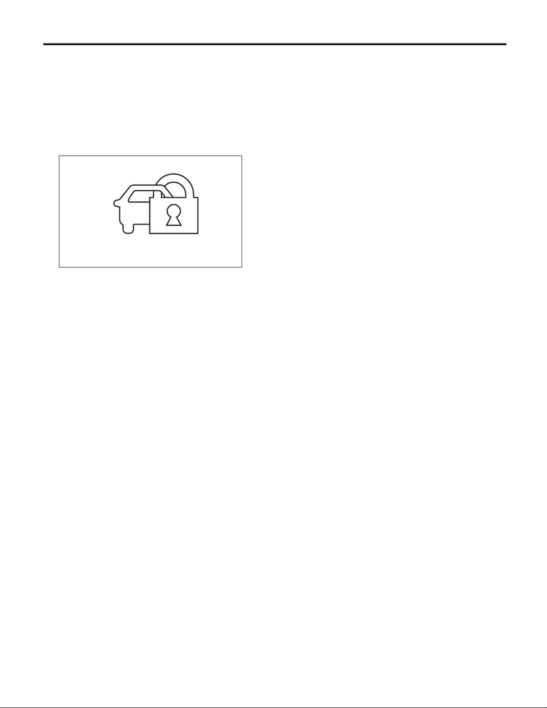

PI-24

Pre-delivery Inspection

PRE-DELIVERY INSPECTION

30.IMMOBILIZER SYSTEM

1) Check that the engine starts with all keys that are equipped on vehicle. Also, when starting the engine,

check that the security indicator light goes off.

2) Check that the security indicator light blinks in 60 seconds after turning the ignition switch from ON to ACC

or to OFF, or immediately after removing the key. Also, when starting the engine, check that the security in-

dicator light goes off. (Model without keyless access function)

3) Immediately after turning ignition switch from ON to OFF, or with the key not in the vehicle and when open-

ing/closing a door while the ignition switch is in ON or ACC with the engine stopped, check that the security

indicator light is blinking. (Model with keyless access function)

NOTE:

If malfunctions occur, refer to “IMMOBILIZER (DIAGNOSTICS)”. <Ref. to IM(diag)-2, Basic Diagnostic Pro-

cedure.>

31.PUSH BUTTON START FUNCTION

•CVT model

1) Get into the vehicle while carrying the access key, with the vehicle in P range and the brake pedal OFF,

and check that every time the push button ignition switch is pressed, that it cycles through ACC → IGN ON

→ IGN OFF, and the indicator light for the push button ignition switch is illuminated in orange.

2) Get into the vehicle while carrying the access key, with the vehicle in P range and the brake pedal ON,

check that the indicator light for the push button ignition switch is illuminated in green.

NOTE:

While the select lever button is being pressed, the indicator light of the push button ignition switch does not

illuminate in green even if the shift position is in the P range.

3) Get into the vehicle while carrying the access key, with the vehicle in P range and the brake pedal ON,

check that the engine starts when you press the push button ignition switch.

4) With the vehicle stopped, the engine running and in P range, check that the engine stops when you press

the push button ignition switch.

5) With the vehicle stopped, the engine running and in N range, check that the engine stops when you press

the push button ignition switch, and cycles through ACC → IGN ON each time you press the push button ig-

nition switch.

• MT model

1) Get into the vehicle while carrying the access key, with the clutch pedal OFF, and check that every time

the push button ignition switch is pressed, that it cycles through ACC → IGN ON → IGN OFF, and the indi-

cator light for the push button ignition switch is illuminated in orange.

2) Get into the vehicle while carrying the access key, with the clutch pedal ON, check that the indicator light

for the push button ignition switch is illuminated in green.

3) Get into the vehicle while carrying the access key, with the clutch pedal ON, check that the engine starts

when you press the push button ignition switch.

4) With the vehicle stopped and the engine running, check that the engine stops when you press the push

button ignition switch.

PI-00773

(1)

(1) Security indicator light

PI-25

Pre-delivery Inspection

PRE-DELIVERY INSPECTION

32.STARTING CONDITION

Start the engine and check that the engine starts smoothly. If the battery voltage is low, recharge or replace

the battery. If any noises are observed, immediately stop the engine and check and repair the abnormal com-

ponents.

33.EXHAUST SYSTEM

Listen to the exhaust noise to see if no exhaust gas leak or abnormal noises are observed.

34.INDICATOR LIGHT AND WARNING LIGHT

Check that all indicator lights and warning lights operate normally.

35.HEATER & VENTILATION

Operate the heater & ventilation system to check for normal airflow outlet control, air inlet control, airflow ca-

pacity and heating performance.

36.AIR CONDITIONER

Operate the air conditioner. Check that the A/C compressor operates normally and enough cooling is provid-

ed.

NOTE:

To prevent the insufficient lubrication of the air conditioner, operate the air conditioner for five minutes at

idling.

37.MULTI-FUNCTION DISPLAY (MFD)

1) Check that the Multi-Function Display (MFD) function operates normally. (Refer to the owner’s manual for

the operation procedures.)

2) Check that the rearview camera operates normally.

38.AUDIO

Check that all radio functions operate, the speakers emit sound properly and the noise is at an acceptable

level. Also check the CD unit and AUX unit operations.

39.NAVIGATION SYSTEM

1) Check all display functions for normal operation. (Refer to the owner’s manual for the operation proce-

dures.)

2) Check that the navigation system operates normally.

3) Check that the rearview camera operates normally.

40.ACCESSORY POWER SUPPLY SOCKET

1) Check the operation of the front accessory power supply socket.

2) Check operation of the accessory power supply socket in console box.

41.LIGHTING SYSTEM

1) Check the headlight operations.

2) Check the stop light operation.

3) Check other lights for normal operations.

4) Check the manual levelers of the halogen headlight for normal operations.

42.WIPER DEICER

Check that the wiper deicer operates normally.

NOTE:

When an ambient temperature is 5°C or more, wiper deicer operation is cancelled. Press the switch for 3 sec-

onds or more to perform the compulsory operation.

43.ILLUMINATION CONTROL

Check that the illumination control operates normally.

PI-26

Pre-delivery Inspection

PRE-DELIVERY INSPECTION

44.WINDOW WASHER

Check that the window washer injects the washer fluid to the specified area of the windshield. <Ref. to WW-

27, ADJUSTMENT, Front Washer Nozzle.>

45.WIPER

Check that the front wiper operates normally.

46.POWER WINDOW

• Operate the power window switches one by one to check that each of the power windows goes up and

down without noises.

• Check AUTO UP/AUTO DOWN operate properly by operating the power window switch on driver’s seat

side.

CAUTION:

If battery has been removed, AUTO UP does not operate properly because initialized. In this case,

perform the initial setting (reset A) and check AUTO UP operates properly.

NOTE:

Check the power window if the door glass of the driver’s seat does not open/close automatically. <Ref. to

GW-9, INSPECTION, Power Window System.>

47.SUNROOF

Check that the sunroof operates normally.

NOTE:

For details concerning sunroof initialization, refer to the “SR” section. <Ref. to SR-6, INITIALIZE OPERA-

TION, OPERATION, Sunroof Control System.>

48.REAR DEFOGGER

Check that the rear defogger operates normally.

49.DOOR MIRROR

Check that the mirror heater and remote control mirror operate normally.

50.PARKING BRAKE

Check the parking brake for normal operations. When pulling the parking brake lever with a force of 200 N

(20 kgf, 45 lb), check that the lever stroke of parking brake lever is 7 to 8 notches.

51.DIAGNOSTIC TROUBLE CODE (DTC) CHECK

Read the diagnostic trouble code and check that the diagnostic trouble code is not detected.

If any diagnostic trouble code is detected, clear all.

1) Read Diagnostic Trouble Code

NOTE:

For detailed operation procedures, refer to “PC application help for Subaru Select Monitor”.

2) Clear Memory Mode

NOTE:

For detailed operation procedures, refer to “PC application help for Subaru Select Monitor”.

52.BRAKE TEST

Check the foot brake for normal operations.

NOTE:

On the model with brake assist mechanism, the brake pedal feels lighter when the brake pedal is depressed

hard or quickly. However, those are not malfunction but the phenomena that occur when the brake assist

mechanism functions properly.

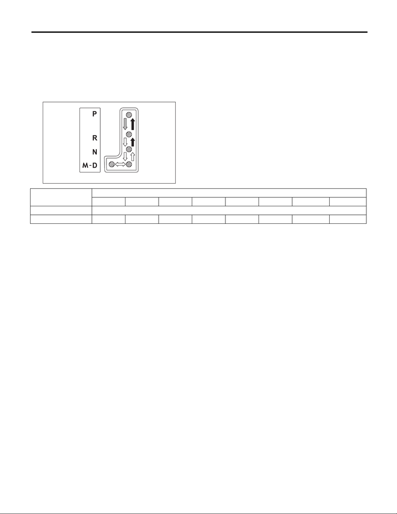

PI-27

Pre-delivery Inspection

PRE-DELIVERY INSPECTION

53.SHIFT CONTROL

•CVT

1) Turn the ignition switch to ON.

2) While brake pedal is not depressed, check if the select lever does not move from “P” range.

3) While brake pedal is depressed, check if the select lever moves from “P” range.

4) Set the selector lever to each gear position and check the shifting while driving the vehicle. Operate the

paddle shift at manual mode and check the shifting while driving the vehicle.

*1: In S# mode

5) Set the select lever to other than “P” range. (Except for models with keyless access function)

6) When the ignition switch is turned to OFF, check if the ignition key switch cannot be removed. (Except for

models with keyless access function)

PI-00880

Selector position

Gear position

1st 2nd 3rd 4th 5th 6th 7th

*1

8th

*1

D Continuously variable speed change

Manual mode OK OK OK OK OK OK OK OK

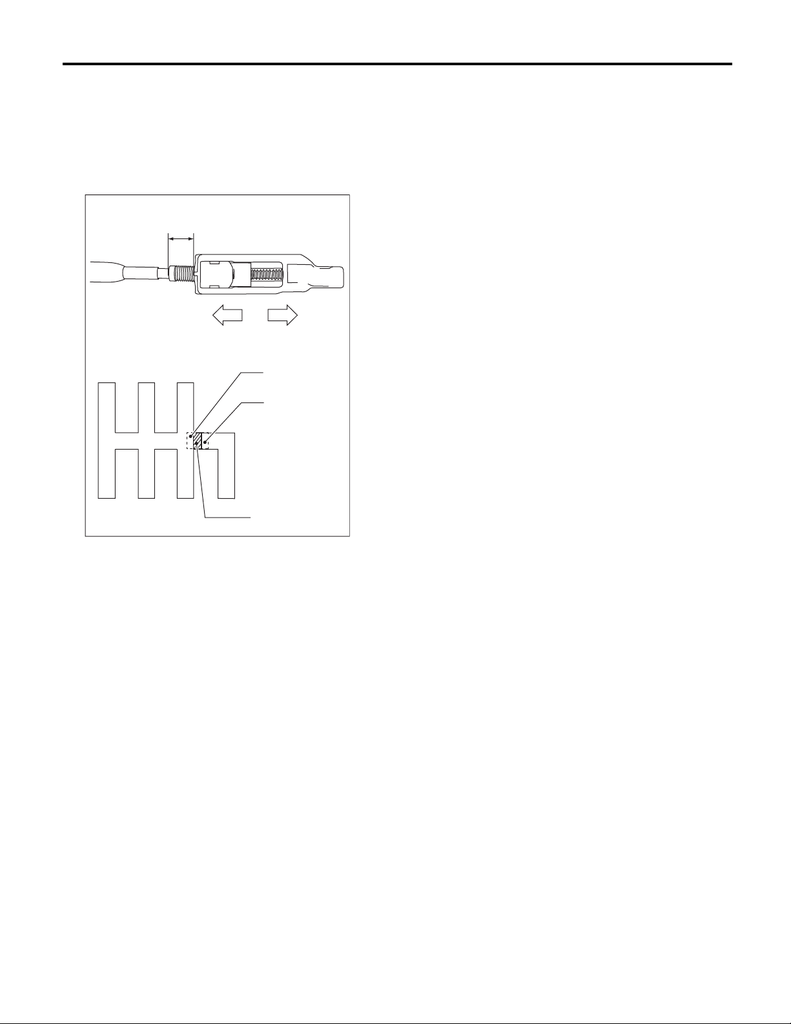

PI-28

Pre-delivery Inspection

PRE-DELIVERY INSPECTION

• 6MT (Except for STI model)

1) Check for smooth operation to each position. Especially, shift to 5th ←→ 6th and to Rev, and check for

stuck.

2) Check the slider returns to the original position by shifting to the Rev and then back in neutral while pulling

up the slider.

3) If the shifting operation is not smooth, readjust the exposed length (a) of MT gear select cable by referring

to the following figure.

• If the shift cannot be inserted to push the reverse lock bracket 5th and 6th.

→ Extend the exposed length (a) of MT gear select cable.

• When operate the select lever to 4th → 5th, it cannot be operated at select lever crank line.

→ Shorten the exposed length (a) of MT gear select cable.

• 6MT (STI model)

1) Check for smooth operation to each position.

2) Check that the lever cannot be moved to the reverse position unless the slider is pulled up.

3) Check that the lever can be moved to the reverse position when the slider is pulled up.

54.CRUISE CONTROL

Operate the cruise control system. Check that the system is activated and deactivated correctly.

CS-01043

1st

2nd

3rd

4th

5th

6th Rev

(a)

(B) (A)

(A)

(C)

(B)

(a) Exposed length of MT gear select cable

(A) Extend direction of exposed length of MT gear

select cable

(B) Shorten direction of exposed length of MT gear

select cable

(C) Specification of exposed length (a)

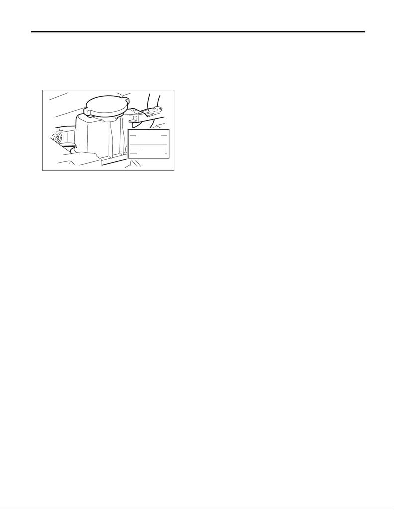

PI-29

Pre-delivery Inspection

PRE-DELIVERY INSPECTION

55.POWER STEERING FLUID LEVEL (HYDRAULIC POWER STEERING MODEL)

CAUTION:

If any power steering fluid is spilt over the exhaust pipe, wipe it off with a cloth to avoid emitting

smoke or causing a fire.

Check that the power steering fluid level is normal. If the amount of power steering fluid is insufficient, check

that no leaks are found. Then add the necessary amount of the specified power steering fluid.

56.POWER STEERING SYSTEM (ELECTRIC POWER STEERING MODEL)

Check that the electric power steering warning light illuminates when the ignition switch is turned to ON, and

that the electric power steering warning light goes off after the engine is started.

57.FLUID LEAKAGE

Check entire areas of the vehicle for any trace of coolant/oil (such as engine and gear oil)/fluid (such as trans-

mission and brake) leaks.

58.WATER LEAK TEST

Spray the vehicle with water using a hose and check that no water enters the passenger compartment.

• Before performing the water leakage test, remove anything that may obstruct the operation or which must

be kept dry.

• Close all the windows and doors securely. Close the front hood and trunk lid before starting the test.

• Spray the vehicle with water using a hose. The rate of water spray must be approx. 20 to 25 L (5.3 — 6.6

US gal, 4.4 — 5.5 Imp gal) per minute.

When spraying water on areas adjacent to the floor and wheel house, increase the pressure. When spraying

water on areas other than the floor and wheel house, decrease the pressure. But the force of water must be

made strong occasionally by pressing the end of the hose.

NOTE:

Be sure to keep the hose at least 10 cm (3.9 in) away from vehicle.

Check the following areas.

• Front window and body framework mating portion

• Door mating portions

• Glass mating portions

• Rear quarter window mating portions

• Rear window and body framework mating portion

• Around roof drips

If any dampness in the compartments is discovered after the water has been applied, carefully check all the

areas that may have possibly contributed to the leak.

PS-00463

HOT MAX

COLD MAX

HOT MIN

COLD MIN

PI-30

Pre-delivery Inspection

PRE-DELIVERY INSPECTION

59.APPEARANCE 2

1) If protective coating (wrap guard) is applied, remove it.

NOTE:

• It is easier to remove the wrap guard using steam.

• For a vehicle left for a long time or at low temperature, sprinkle some water heated to 50 — 60°C (122 —

140°F) over the vehicle to raise its surface temperature before peeling off the wrap guard. Do not use the wa-

ter heated to over 60°C (140°F).

• If the adhesive remains exist on the coated surface, soak a flannel rag, etc. with a small amount of coating

wax or solvent such as oil benzene and IPA, put the soaked cloth on the remains lightly, and then wipe them

off with a flannel rag etc.

• Keep solvent from touching the resin or rubber parts. Do not use coating wax or solvent while the compo-

nent surface temperature is high due to hot weather etc.

• If the coated surface is swollen out due to seams or moisture, expose the vehicle to the sunlight for a few

hours or heat the seam and swollen portions using a dryer etc.

• Dispose of the peeled wrap guard as burnable industrial garbage.

• If any label is attached to the fog light lens, remove it.

2) Check the whole vehicle body for flaking paint, damage by transportation, corrosion, dirt, cracks or blis-

ters.

NOTE:

• It is better to determine an inspection pattern in order to avoid missing an area, since the total inspection

area is wide.

• Do not repair the body paint unless absolutely necessary. Also, if the vehicle is in need of repair to remove

scratches or corroded paint, the repair area must be limited to the minimum. Re-painting and spray painting

must be avoided as much as possible.

3) Check each window glass for scratches carefully. Slight damage may be removed by polishing with cerium

oxide. (Fill a cup half with cerium oxide, and add warm water to it. Then agitate the content until it turns to

wax. Apply this wax to a soft cloth, and polish the glass with it.)

4) Check each portion of the vehicle body and underside components for the formation of rust. If rust is dis-

covered, remove it with sandpaper of #80 to #180 and treat the surface with rust preventive. After this treat-

ment is completed, flush the portion thoroughly, and prepare the surface for repair painting.

5) Check each portion of body and all of the exterior parts for deformation or distortion. Also, check each light

lens for cracks.

6) Peel the protective tape, vinyl wrapping and identification seal attached to the following places.

• Seat

• Door trim

• Floor carpet

• Side sill (with SUS plate RH/LH)

• Front hood lock release lever

• Fuel opener lever

• Door mirror

• Front fog light

• Rear shelf

• Aluminum pedal

[figure not shown]

PERIODIC MAINTENANCE SERVICES

PM

Page

1. General Description ...................................................................................2

2. Schedule ....................................................................................................3

3. Engine Oil ...................................................................................................6

4. Engine Oil Filter ..........................................................................................7

5. Spark Plug ..................................................................................................8

6. V-belt ..........................................................................................................9

7. Timing Belt ...............................................................................................10

8. Fuel Line ..................................................................................................11

9. Fuel Filter .................................................................................................12

10. Air Cleaner Element .................................................................................13

11. Cooling System ........................................................................................14

12. Engine Coolant .........................................................................................15

13. Clutch System ..........................................................................................16

14. Transmission Gear Oil .............................................................................17

15. CVTF ........................................................................................................18

16. Front & Rear Differential Gear Oil ............................................................19

17. Brake Line ................................................................................................20

18. Brake Fluid ...............................................................................................22

19. Disc Brake Pad and Disc .........................................................................23

20. Parking Brake ...........................................................................................24

21. Suspension ..............................................................................................25

22. Wheel Bearing ..........................................................................................29

23. Axle Boots & Joints ..................................................................................30

24. Tire Inspection and Rotation ....................................................................31

25. Steering System (Power Steering) ...........................................................32

26. A/C Filter ..................................................................................................37